# ASRI Regression Lab

Dr. Weijia Jia

2023-06-08

# What is regression?

First, let’s introduce linear regression with a very simple example.

#### Scatterplot

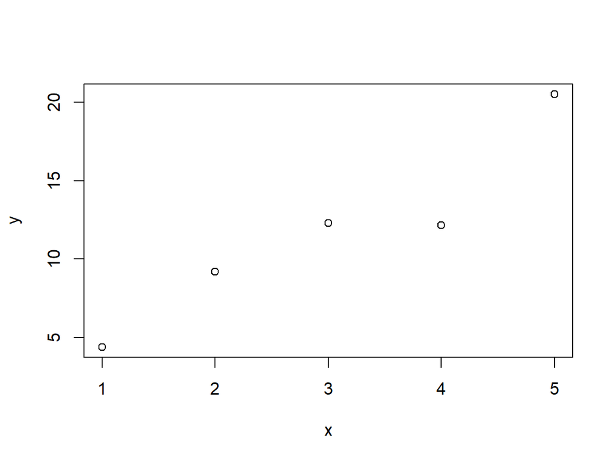

```r
# A simple example with x and y defined below
# x is called predictor
# y is called response

x <- c(1, 2, 3, 4, 5)
y <- c(4.39, 9.18, 12.31, 12.17, 20.53)

# Draw the scatterplot
plot(x, y)
```

#### Best-fitted line

- The best-fitted line is the line fits the data the best (using the least squares method).
- The *best-fitted line* is also called the *regression line*, or *the least squares regression line*.
- The equation of the best-fitted line is called **estimated regression equation**.
- The estimated regression equation is denoted as $\hat{y} = b_0 + b_1 x$. (Recall $y=mx+b$ the slope-intercept form of a linear equation. )
- $b_0$ is the intercept of the estimated regression equation.
- $b_1$ is the slope of the estimated regression equation.

```r
fit = lm(y~x)
```

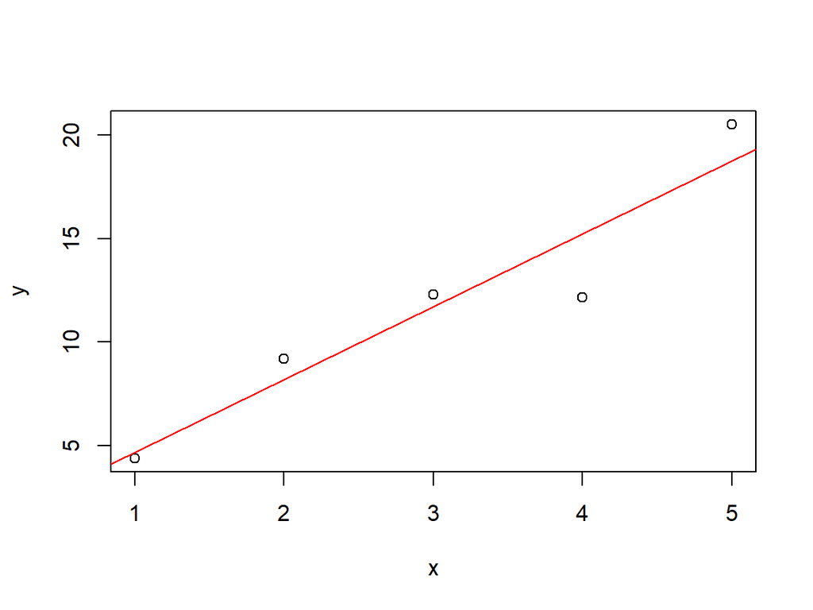

```r
# Draw the best-fitted line on the scatterplot
plot(x,y)
abline(fit, col="red")
```

```r
summary(fit)
```

```
##
## Call:
## lm(formula = y ~ x)
##
## Residuals:
##      1      2      3      4      5
## -0.272  0.991  0.594 -3.073  1.760
##
## Coefficients:
##             Estimate Std. Error t value Pr(>|t|)
## (Intercept)   1.1350     2.2616   0.502    0.650
## x             3.5270     0.6819   5.172    0.014 *
## ---
## Signif. codes:  0 '***' 0.001 '**' 0.01 '*' 0.05 '.' 0.1 ' ' 1
##
## Residual standard error: 2.156 on 3 degrees of freedom
## Multiple R-squared:  0.8992, Adjusted R-squared:  0.8656
## F-statistic: 26.75 on 1 and 3 DF,  p-value: 0.01402
```

For this question, the *estimated regression equation* is $\hat{y} = 1.135 + 3.527 x$. You could find these statistics from the output above or using `coef(fit)`.

```r
# Find the coefficient of best-fitted line
coef(fit)
```

```
## (Intercept)           x
##       1.135       3.527
```

# Let’s summarize the code we’ve used

```r
# x is predictor, y is response
x <- c(1, 2, 3, 4, 5)
y <- c(4.39, 9.18, 12.31, 12.17, 20.53)

# Draw the scatterplot
plot(x, y)

# Fit the model
fit = lm(y~x)

# Add the regression line to the scatterplot
plot(x,y)
abline(fit, col="red")

# Find the summary statistics of the model
summary(fit)

# Find the coefficients of the model
coef(fit)

# (Additional advanced topic) Examine residual plots
par(mfrow=c(2,2))
plot(fit)
par(mfrow=c(1,1)) # change back to default setting
```

# Boston Example

The Boston dataset from the **MASS** package in R contains information about various attributes for suburbs in Boston, Massachusetts.

This lab will investigate predicting median house value (medv) using other predictors.

Let’s learn more about the dataset, including variable names and features.

```r
library(MASS)

# load the data
data(Boston)

# get variable names
names(Boston)
```

```
##  [1] "crim"    "zn"      "indus"   "chas"    "nox"     "rm"      "age"
##  [8] "dis"     "rad"     "tax"     "ptratio" "black"   "lstat"   "medv"
```

```r
# get info about the data set
str(Boston)
```

```
## 'data.frame':    506 obs. of  14 variables:
##  $ crim   : num  0.00632 0.02731 0.02729 0.03237 0.06905 ...
##  $ zn     : num  18 0 0 0 0 0 12.5 12.5 12.5 12.5 ...
##  $ indus  : num  2.31 7.07 7.07 2.18 2.18 2.18 7.87 7.87 7.87 7.87 ...
##  $ chas   : int  0 0 0 0 0 0 0 0 0 0 ...
##  $ nox    : num  0.538 0.469 0.469 0.458 0.458 0.458 0.524 0.524 0.524 0.524 ...
##  $ rm     : num  6.58 6.42 7.18 7 7.15 ...
##  $ age    : num  65.2 78.9 61.1 45.8 54.2 58.7 66.6 96.1 100 85.9 ...
##  $ dis    : num  4.09 4.97 4.97 6.06 6.06 ...
##  $ rad    : int  1 2 2 3 3 3 5 5 5 5 ...
##  $ tax    : num  296 242 242 222 222 222 311 311 311 311 ...
##  $ ptratio: num  15.3 17.8 17.8 18.7 18.7 18.7 15.2 15.2 15.2 15.2 ...
##  $ black  : num  397 397 393 395 397 ...
##  $ lstat  : num  4.98 9.14 4.03 2.94 5.33 ...
##  $ medv   : num  24 21.6 34.7 33.4 36.2 28.7 22.9 27.1 16.5 18.9 ...
```

```r
# examine data
head(Boston)
```

```
##      crim zn indus chas   nox    rm  age    dis rad tax ptratio  black lstat
## 1 0.00632 18  2.31    0 0.538 6.575 65.2 4.0900   1 296    15.3 396.90  4.98
## 2 0.02731  0  7.07    0 0.469 6.421 78.9 4.9671   2 242    17.8 396.90  9.14
## 3 0.02729  0  7.07    0 0.469 7.185 61.1 4.9671   2 242    17.8 392.83  4.03
## 4 0.03237  0  2.18    0 0.458 6.998 45.8 6.0622   3 222    18.7 394.63  2.94
## 5 0.06905  0  2.18    0 0.458 7.147 54.2 6.0622   3 222    18.7 396.90  5.33
## 6 0.02985  0  2.18    0 0.458 6.430 58.7 6.0622   3 222    18.7 394.12  5.21
##   medv
## 1 24.0
## 2 21.6
## 3 34.7
## 4 33.4
## 5 36.2
## 6 28.7
```

# Fit linear regression model to Boston Data

```r
# the formula syntax is model = lm(response~predictor, data = )
lm.fit=lm(medv~lstat, data = Boston)

# inspect the linear model info
summary(lm.fit)
```

```
##
## Call:
## lm(formula = medv ~ lstat, data = Boston)
##
## Residuals:
##     Min      1Q  Median      3Q     Max
## -15.168  -3.990  -1.318   2.034  24.500
##
## Coefficients:
##             Estimate Std. Error t value Pr(>|t|)
## (Intercept) 34.55384    0.56263   61.41   <2e-16 ***
## lstat       -0.95005    0.03873  -24.53   <2e-16 ***
## ---
## Signif. codes:  0 '***' 0.001 '**' 0.01 '*' 0.05 '.' 0.1 ' ' 1
##
## Residual standard error: 6.216 on 504 degrees of freedom
## Multiple R-squared:  0.5441, Adjusted R-squared:  0.5432
## F-statistic: 601.6 on 1 and 504 DF,  p-value: < 2.2e-16
```

```r
# Find the coefficient
coef(lm.fit)
```

```
## (Intercept)       lstat
##  34.5538409  -0.9500494
```

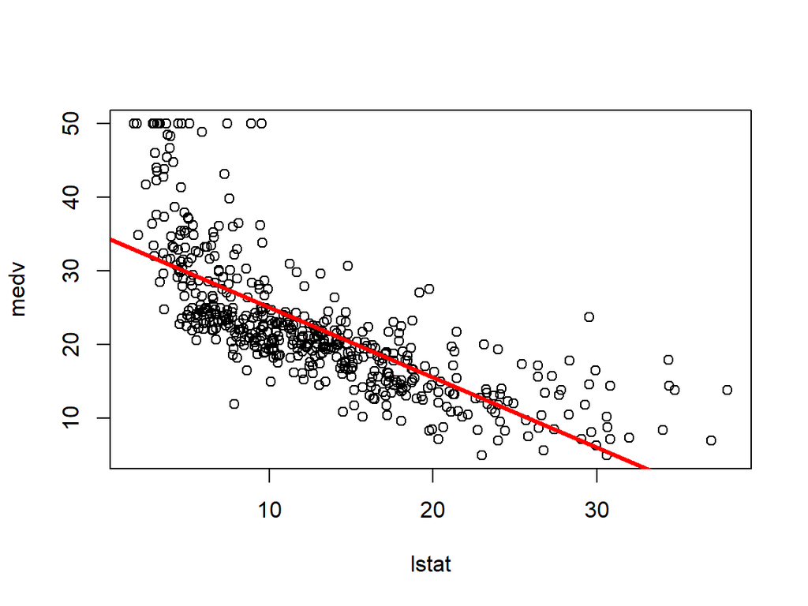

```r
# Draw the best-fitted line to the scatterplot
attach(Boston)
plot(lstat,medv)
abline(lm.fit, col="red", lwd=3)
```

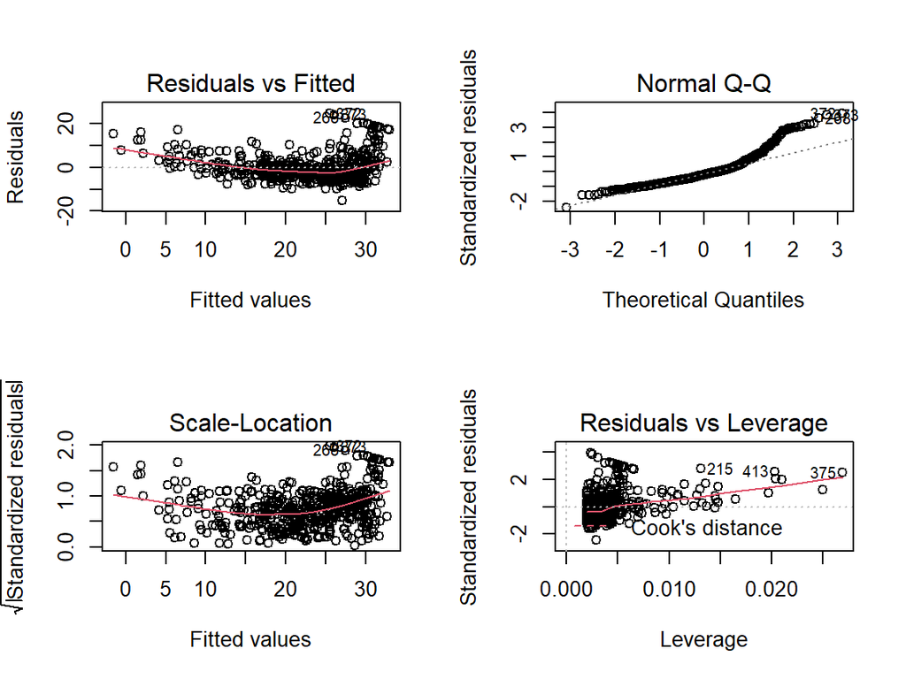

```r
# split screen and show multiple residual plots of lm.fit
par(mfrow=c(2,2))
plot(lm.fit)
```

```r
par(mfrow=c(1,1))
```

Ideally, the residual plot will show no fitted discernible pattern. The presence of a pattern may indicate a problem with some aspect of the linear model.

# Something to check about the output

- The estimated regression equation

$$\hat{y} = b_0 + b_1 x = 34.55 - 0.95
x$$

- The $p$-value for the predictor

From the output, the $p$-value is $<2e-16$ (essentially 0), which is less than 0.05. Therefore, `lstat` is an important predictor for `medv`.

- The r-squared (also called the coefficient of determination).

– r-squared is the proportion of variation in the response variable that is explained by the predictor variable in the model.

– The closer the r-squared value is to 1, the better the fit.

– An r-squared value of 0 indicates that the regression line does not fit the data at all, while an r-squared value of 1 indicates a perfect fit.

From the output, the r-squared value is $54.41\%$. This means there are $54.41\%$ of of the variability observed in the response variable `medv` is explained by the linear relationship between `medv` and `lstat`.

# Fit multiple linear regression

- With only one predictor, the regression is called simple linear regression
- With more than one predictors, the regression is multiple linear regression.
- No matter simple linear regression or multiple linear regression, there are always only **one** response variable.

```r
# the formula syntax is model = lm(response~predictor1 + predictor2 + ... + predictorp, data = )
boston.mlr=lm(medv~lstat + rm + dis + ptratio + chas, data = Boston)

# inspect the linear model info
summary(boston.mlr)
```

```
##
## Call:
## lm(formula = medv ~ lstat + rm + dis + ptratio + chas, data = Boston)
##
## Residuals:
##      Min       1Q   Median       3Q      Max
## -17.9355  -2.9712  -0.6246   1.8183  27.3931
##
## Coefficients:
##             Estimate Std. Error t value Pr(>|t|)
## (Intercept) 23.46692    4.05271   5.790 1.24e-08 ***
## lstat       -0.65845    0.04637 -14.198  < 2e-16 ***
## rm           4.17966    0.42016   9.948  < 2e-16 ***
## dis         -0.49227    0.12715  -3.871 0.000123 ***
## ptratio     -0.93220    0.11569  -8.058 5.75e-15 ***
## chas         2.92247    0.90989   3.212 0.001404 **
## ---
## Signif. codes:  0 '***' 0.001 '**' 0.01 '*' 0.05 '.' 0.1 ' ' 1
##
## Residual standard error: 5.091 on 500 degrees of freedom
## Multiple R-squared:  0.6966, Adjusted R-squared:  0.6935
## F-statistic: 229.6 on 5 and 500 DF,  p-value: < 2.2e-16
```

```r
# Find the coefficient
coef(boston.mlr)
```

```
## (Intercept)       lstat          rm         dis     ptratio        chas
##  23.4669217  -0.6584523   4.1796569  -0.4922665  -0.9322010   2.9224713
```

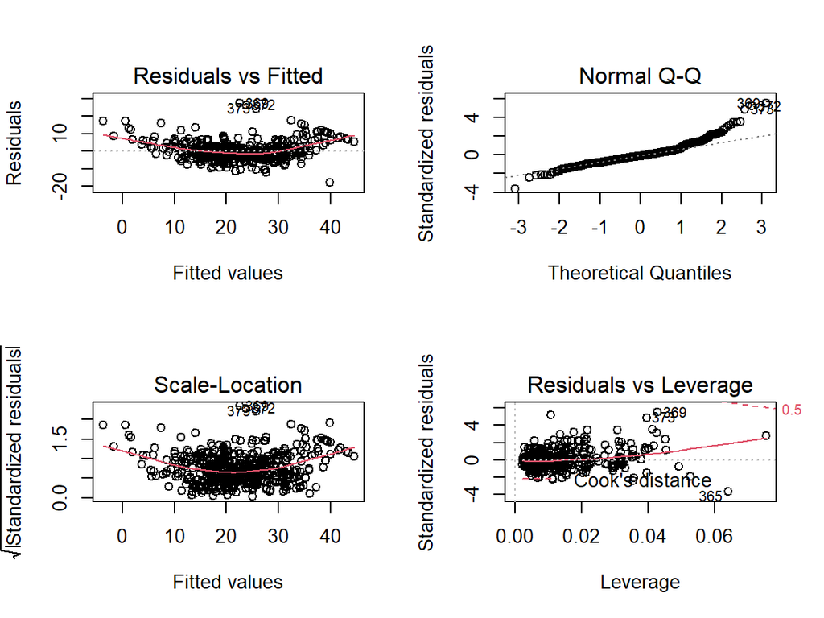

```r
# split screen and show multiple residual plots of lm.fit
par(mfrow=c(2,2))
plot(boston.mlr)
```

```r
par(mfrow=c(1,1))
```

From the output, the r-squared value is $69.66\%$. This means there are $69.66\%$ of of the variability observed in the response variable `medv` is explained by this multiple linear regression model.

# Fit linear regression model to diabetes data

Please read in the diabetes data into R. Name the data frame as `diab`. Then fit the regression model using

- predictor variable – age
- response variable – bmi

```r
# the formula syntax is model = lm(response~predictor, data = )
diab.lmfit=lm(bmi~age, data = diab)

# inspect the linear model info
summary(diab.lmfit)
```

```
##
## Call:
## lm(formula = bmi ~ age, data = diab)
##
## Residuals:
##     Min      1Q  Median      3Q     Max
## -21.101  -3.791  -0.788   2.512  71.839
##
## Coefficients:
##              Estimate Std. Error t value Pr(>|t|)
## (Intercept) 2.316e+01  4.173e-02   554.9   <2e-16 ***
## age         9.945e-02  8.774e-04   113.3   <2e-16 ***
## ---
## Signif. codes:  0 '***' 0.001 '**' 0.01 '*' 0.05 '.' 0.1 ' ' 1
##
## Residual standard error: 6.248 on 99998 degrees of freedom
## Multiple R-squared:  0.1138, Adjusted R-squared:  0.1138
## F-statistic: 1.285e+04 on 1 and 99998 DF,  p-value: < 2.2e-16
```

```r
# Find the coefficient
coef(diab.lmfit)
```

```
## (Intercept)         age
## 23.15536202  0.09944658
```

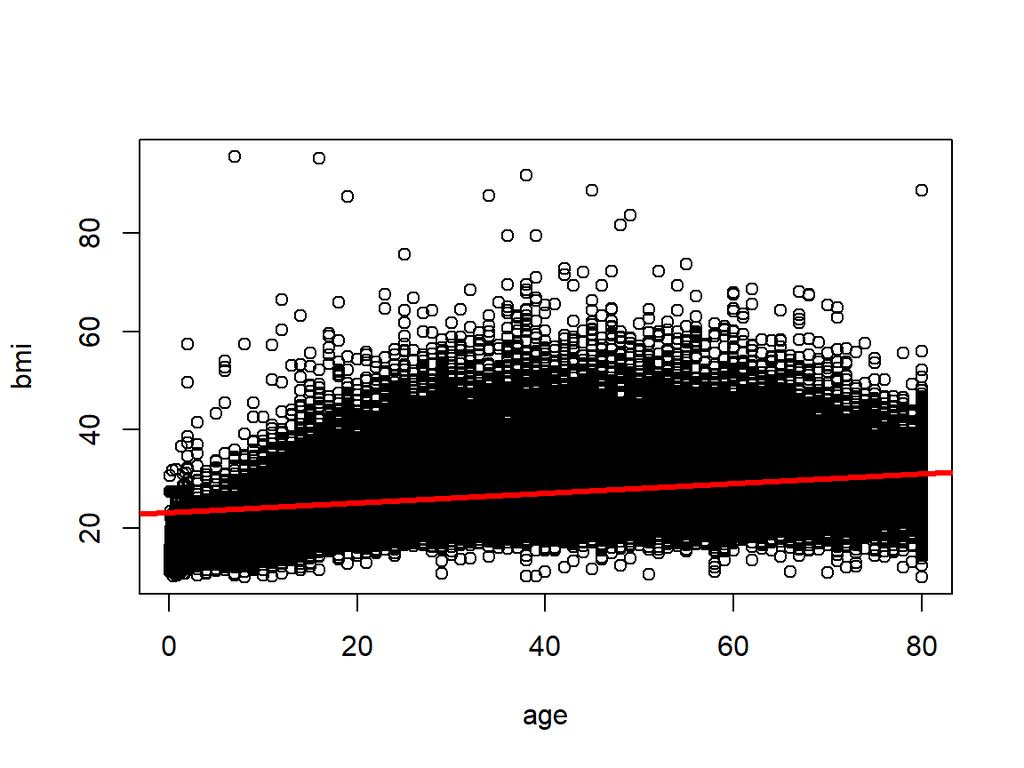

```r
# Draw the best-fitted line to the scatterplot
attach(diab)
plot(age,bmi)
abline(diab.lmfit, col="red", lwd=3)
```

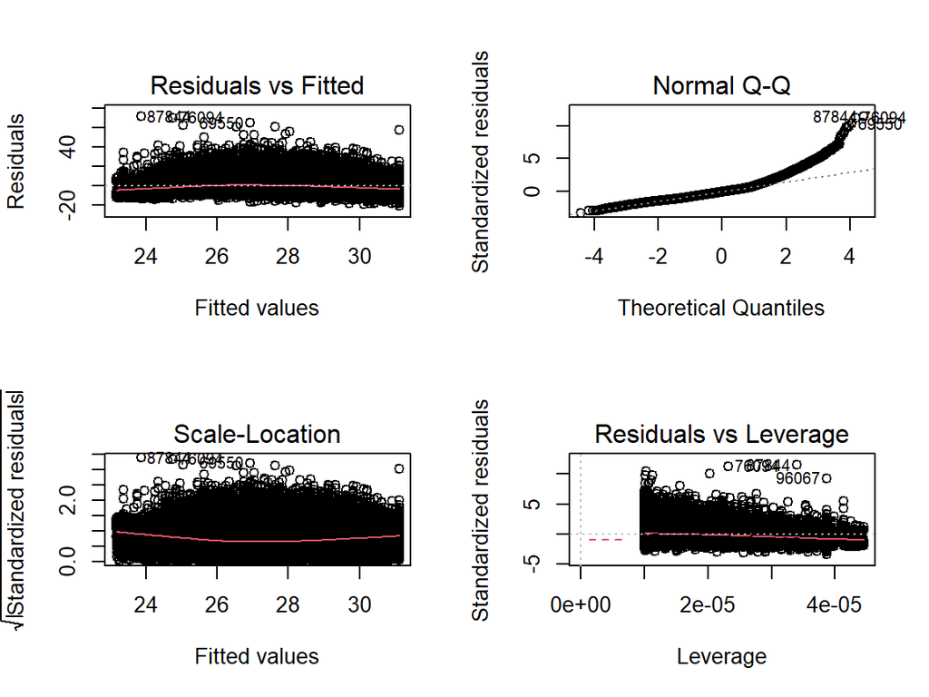

```r
# split screen and show multiple residual plots of lm.fit
par(mfrow=c(2,2))
plot(diab.lmfit)
```

```r
par(mfrow=c(1,1))
```

# Introduce Logistic Regression for diabetes data

The major objective of the diabetes data is to predict diabetes in patients based on their medical history and demographic information.

In this case, the ordinary linear regression method doesn’t work any longer. Why?

Answer: The response variable is not continuous variable. The response variable is categorical (0– no diabetes, 1 – with diabetes).

Therefore, we need to use logistic regression instead.

#### Fit the logistic regression using glm() function

```r
# the formula syntax of logistic regression is model = glm(response~predictors, data = , family=binomial)

diab.glm = glm(diabetes~gender + age + hypertension + heart_disease + smoking_history + bmi + HbA1c_level + blood_glucose_level, data=diab, family=binomial)
summary(diab.glm)
```

```
##
## Call:
## glm(formula = diabetes ~ gender + age + hypertension + heart_disease +
##     smoking_history + bmi + HbA1c_level + blood_glucose_level,
##     family = binomial, data = diab)
##
## Deviance Residuals:
##     Min       1Q   Median       3Q      Max
## -2.7657  -0.1962  -0.0664  -0.0173   3.8133
##
## Coefficients:
##                              Estimate Std. Error z value Pr(>|z|)
## (Intercept)                -2.708e+01  2.929e-01 -92.455  < 2e-16 ***
## genderMale                  2.724e-01  3.613e-02   7.540 4.69e-14 ***
## genderOther                -9.475e+00  1.029e+02  -0.092  0.92664
## age                         4.620e-02  1.126e-03  41.040  < 2e-16 ***
## hypertension                7.413e-01  4.710e-02  15.737  < 2e-16 ***
## heart_disease               7.346e-01  6.072e-02  12.099  < 2e-16 ***
## smoking_historyever        -5.097e-02  9.248e-02  -0.551  0.58154
## smoking_historyformer      -1.084e-01  7.009e-02  -1.546  0.12203
## smoking_historynever       -1.566e-01  6.057e-02  -2.586  0.00971 **
## smoking_historyNo Info     -7.304e-01  6.651e-02 -10.981  < 2e-16 ***
## smoking_historynot current -2.114e-01  8.332e-02  -2.538  0.01115 *
## bmi                         8.895e-02  2.555e-03  34.819  < 2e-16 ***
## HbA1c_level                 2.340e+00  3.578e-02  65.413  < 2e-16 ***
## blood_glucose_level         3.336e-02  4.821e-04  69.207  < 2e-16 ***
## ---
## Signif. codes:  0 '***' 0.001 '**' 0.01 '*' 0.05 '.' 0.1 ' ' 1
##
## (Dispersion parameter for binomial family taken to be 1)
##
##     Null deviance: 58163  on 99999  degrees of freedom
## Residual deviance: 22627  on 99986  degrees of freedom
## AIC: 22655
##
## Number of Fisher Scoring iterations: 12
```

```r
coef(diab.glm)
```

```
##                (Intercept)                 genderMale
##               -27.08466020                 0.27244439
##                genderOther                        age
##                -9.47529283                 0.04619853
##               hypertension              heart_disease
##                 0.74125010                 0.73462512
##        smoking_historyever      smoking_historyformer
##                -0.05096853                -0.10837871
##       smoking_historynever     smoking_historyNo Info
##                -0.15662984                -0.73041040
## smoking_historynot current                        bmi
##                -0.21144411                 0.08895400
##                HbA1c_level        blood_glucose_level
##                 2.34020228                 0.03336244
```

```r
diab.prob=predict(diab.glm,type="response")
diab.prob[1:10]
```

```
##            1            2            3            4            5            6
## 0.3884208506 0.0083608703 0.0096161828 0.0015571302 0.0258420635 0.0036624497
##            7            8            9           10
## 0.1669985383 0.0028205910 0.0025590156 0.0002495857
```

```r
diab.pred=rep("0",nrow(diab))
diab.pred[diab.prob>0.5]="1"

# small confusion matrix
table(diab.pred, diab$diabetes)
```

```
##
## diab.pred     0     1
##         0 90681  3148
##         1   819  5352
```

```r
# 5352 true positives, 90681 true negatives
(5352+90681)/100000
```

```
## [1] 0.96033
```

```r
# Accuracy is 96.033%

mean(diab.pred==diab$diabetes)
```

```
## [1] 0.96033
```